# Introduction to Computational Text Analysis and Supervised Machine Learning in R

Vlad Achimescu, University of Mannheim, v.achimescu@uni-mannheim.de  
17/04/2019, Exeter Q-Step centre

### Overview

1.Computational propaganda

- methods of identification
- list of Reddit trolls
- explore Reddit dataset

2.Text as data

- Text processing
- Document-term matrix
- Example with Reddit submission titles

3.Basics of Machine Learning

- Lasso regression
- Random forests
- Identifying trolls on Reddit

4.Pipeline to apply to your own data or improve model on Reddit  
https://github.com/nomoteticus/mltext-tutorial-2019

### Computational propaganda

= “the use of algorithms, automation and human curation to purposefully manage and distribute misleading information over social media networks” (Wooley and Howard 2018)

- Pseudo-users: political bots, trolls, cyborgs
- (semi-)automation, scalability, anonimity
- Political astroturfing used for:
  - manufacturing or breaking consensus
  - bandwagon effect
  - democratizing propaganda
  - attacking political adversaries
  - voter demobilization
- State-sponsored trolling

### State-sponsored trolling

[figure not shown]

[figure not shown]

[figure not shown]

### Labeling propaganda

1. Hand coding by researchers
   - Stukal et al. 2017
2. Use pre-existing labels:
   - official flags
     - Im Jane et al. 2019
   - informal flags
     - Mihaylov et al. 2018
     - Achimescu, Sultanescu and Sultanescu 2018
       - [BigSurv2018 conference](https://www.bigsurv18.org/program?sess=56)
       - [Poster at GOR2019 conference](https://www.gor.de/gor19/index.php?page=browseSessions&form_session=22&presentations=show)

#### Example of informal flag:

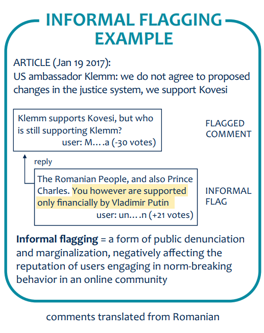

##### (Achimescu, Sultanescu, Sultanescu 2018)

### Official flags

U.S. congress investigations and/or information provided by the platforms themselves

- Twitter:
  - 10 million tweets by around 4,600 Russian and Iranian-linked propaganda accounts
  - https://www.politico.eu/article/how-twitter-bots-and-trump-fans-made-releasethememo-go-viral/
  - https://democrats-intelligence.house.gov/uploadedfiles/exhibit_b.pdf
- Facebook ads
  - https://democrats-intelligence.house.gov/social-media-content/social-media-advertisements.htm
  - https://mith.umd.edu/irads/items/tags
- Reddit: suspect accounts
  - https://www.reddit.com/r/announcements/comments/8bb85p/reddits_2017_transparency_report_and_suspect/

### The Reddit trolls

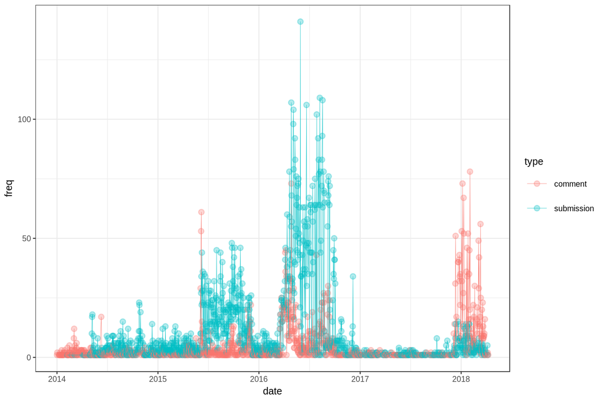

### Scraping data from Reddit

- manual html scraping
  - BeautifulSoup / rvest
  - not reccomended
- using Reddit API
  - PRAW / RedditExtractoR
  - limited to 1000 items
- downloading from www.pushshift.io/reddit
  - submissions
  - comments

### Let's see the data!

```r
### For data manipulation
install.packages("dplyr","readr")
### For text processing
install.packages("quanteda")
### For machine learning
install.packages("caret","glmnet",
                 "randomForests","pdp")

library(dplyr)
library(readr)

### Piping operator %>%
rev(sort(round(log(rnorm(100, 5, 1),2))))
### Equivalent
rnorm(100, 5, 1) %>%
  log(2) %>% round %>% sort %>% rev
```

### Text as Data

- Corpus = a collection of texts/documents
- Corpora often come with metadata
- Bag of words approach
  - Count of words for each document in corpus
  - Discards word order, ignores word meaning
  - Purpose: reduction of complexity
- Pre-processing steps:
  - tokenization
  - removing irrelevant features
  - stemming/lemmatization
  - creating a document-term matrix(DTM)
  - weighting the DTM

### Computational text analysis

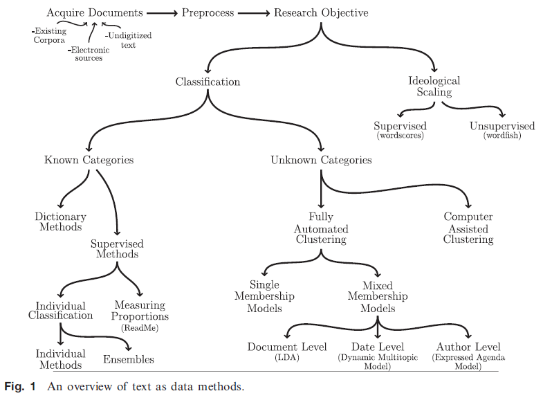

*(Grimmer and Stewart 2013:2)*

### Not covered in this seminar

- Part of Speech (POS) tagging
- Named entity recognition (NER)
- Word Sense Disambiguation (WordNet)
- Word embeddings (word2vec)
- Deep learning

### Tokenization

Text: “X and Y are 2 Kremlin trolls! Trolling day and night for a few rubles.”

- Tokens
  - Sentences [“X and Y are 2 Kremlin trolls !”,“Trolling day and night for a few rubles.”]
  - Words / Unigrams [“X”, “and”, “Y”, “are”, “2”, “Kremlin”, “trolls”, “!”,“Trolling”, …, “rubles”,“.”]
  - Letters
- N-grams
  - Bigrams […,“Kremlin trolls”,“a few”,“few rubles”,…]
  - Trigrams […,“day and night”,…]
  - Skip-grams [“are Kremlin trolls”,…“trolling for rubles”,…]

### Text pre-processing

Text: “X and Y are 2 Kremlin trolls! Trolling day and night for a few rubles.”

- remove capitalization  
  Kremlin -> kremlin
- remove stopwords  
  ![“and”,“a”,“for”,“few”,“here”]
- (remove non-words: numbers, punctuation)  
  [“2”,“!”,“.”]

Next steps:

- combine similar terms (stemming, lemmatization)
- create a Document-Term Matrix

### Stemming vs Lemmatization

Many-to-one mapping from words to stem/lemma

### Stemming

- reducing inflected words to their word stem
- cutting off common suffixes  
  trolling -> troll  
  trolls -> troll  
  rubles -> rubl

### Lemmatization

- based on morphological analysis of each word  
  are -> be

### Let's tokenize and clean the texts!

```r
install.packages("quanteda")
library(quanteda)

CRP = corpus(data_frame,
             docid_field,
             textid_field)
# Alternative:
CRP = corpus(vector_of_documents)

TOK = tokens(CRP)
```

### Document-Term Matrix (DTM)

- Each document = a vector of word counts
- N (number of documents) rows X P (number of features) columns
- Discards word order, ignores word meaning
- Large and sparse matrix (many 0s)
- Main Input for Supervised Machine Learning

Text1: “X and Y are 2 Kremlin trolls! Trolling day and night for a few rubles.”  
Text2: “Kremlin's trolls are here tonight”  
Text3: “Days are few and long”

[output not shown]

### Normalization and Weighting

### Normalization (relative frequencies)

- proportions of the feature counts within each document \[ \mu_{j} = \frac{\sum_{i=1}^{P}tf_{ij}}{N_{j}} \]

### TF-IDF weighting

- Term Frequency - Inverse Document Frequency \[ w_{i,j} = tf_{i,j}\cdot log(\frac{N}{df_{i}}) \]

|  | x | y | kremlin | troll | day | night | rubl | tonight | long |
| --- | --- | --- | --- | --- | --- | --- | --- | --- | --- |
| text1 - normalized | 0.125 | 0.125 | 0.125 | 0.250 | 0.125 | 0.125 | 0.125 | 0 | 0 |
| text1 - TF-IDF | 0.477 | 0.477 | 0.176 | 0.352 | 0.176 | 0.477 | 0.477 | 0 | 0 |
| text1 - TF-IDF normalized | 0.059 | 0.059 | 0.022 | 0.044 | 0.022 | 0.059 | 0.059 | 0 | 0 |

### Let's build the DFM!

```r
library(quanteda)

CRP = corpus(data_frame)
TOK = tokens(CRP)
DFM = dfm(TOK)
```

### Machine learning

#### Goal: building a statistical model for predicting or estimating an output based on one or more inputs

- **X** = Inputs / Features
  - ~ Independent variables
- **y** = Output / Response
  - ~ Dependent variable

|  | Inputs (**X**) |  |  | Output (**y**) |  |
| --- | --- | --- | --- | --- | --- |
| x1 | 1 | 0 | 2 | TROLL | y1 |
| x2 | 0 | 0 | 5 | not troll | y2 |
| x3 | 0 | 1 | -2 | not troll | y3 |

### Supervised ML

- learn mapping from inputs to outputs given a labeled set of input-output pairs
- use mapping on new (unlabeled) inputs
- task depends on measurement level of Y
  - Y is categorical: classification (2+ classes)
  - Y is continuous: regression

### Unupervised ML

- find patterns in data given only inputs  
  (no Y)
- e.g. clustering

### Supervised machine learning for document classification

- documents are automatically coded according to previously defined content categories by training a computer to replicate the coding decisions of humans
- hand coding is used to train, or supervise, statistical models to classify texts in pre-determined categories.
- goal is to classify unknown documents by using the hand-coding to “train” or “supervise” statistical models to classify the remaining documents
- can use the document-term matrix as input, along with available metadata

### Training and test set

- Split the set of observations into **a training set** and **a test set**
- Learn the relationship between input and output using **only** training data
- Check the prediction error on test data, see if overfitting:

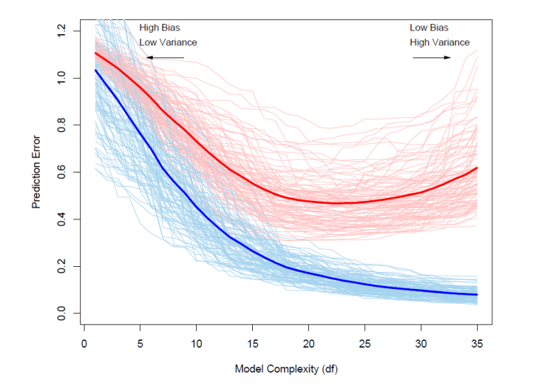

### Let's prepare data for ML!

```r
install.packages("caret","glmnet","randomForests")
library(caret)
```

### Cross-validation

- randomly divide the set of observations into *k* groups (5,10) of equal size
- used for model selection
  - for k = 1..K, train on all folds but kth, validate on kth
  - average of k estimates of test error \[ CV_{k}=\frac{1}{k}\sum_{i=1}^{k}{Err_{i}} \] \[ Err_{i}=I(y_{i} \neq \hat{y}_{i}) \]

    |  | 1 | 2 | 3 | 4 | 5 |
    | --- | --- | --- | --- | --- | --- |
    | k=1 | **VALIDATE** | train | train | train | train |
    | k=2 | train | **VALIDATE** | train | train | train |
    | k=3 | train | train | **VALIDATE** | train | train |
    | k=4 | train | train | train | **VALIDATE** | train |
    | k=5 | train | train | train | train | **VALIDATE** |

- can also do repeated cross-validation

### Model selection

Many different methods/classifiers:

- Logistic regression
- Regularized logistic regression
  - Ridge Regression
  - **The Lasso**
  - Elastic net
- K nearest neighbours
- Naive Bayes
- Support vector machines
- Neural networks
- Generalized additive models (GAMs)
- Tree-based methods
  - Classification trees (CART)
  - Bagging
  - Boosting
  - **Random forests**

There is no single best model that works optimally for all datasets

### Model evaluation

Confusion matrix: TRUE/FALSE positives/negatives

Accuracy

Precision

Recall

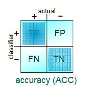

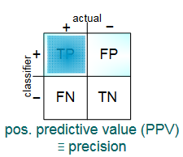

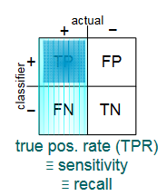

\( \frac{TP+TN}{TP+FP+FN+TN} \)

\( \frac{TP}{TP+FP} \)

\( \frac{TP}{TP+FN} \)

F1 is a balanced measure of precision and recall  
\( F1 = 2*\frac{precision*recall}{precision+recall} \)

### Supervised ML - summary

```r
library(caret)
library(glmnet)
library(randomForest)
```

### The Lasso

Problem: large number of features K>>N  
Solution: Logistic regression with L1 norm/penalty

- shrinks some coefficients to 0

Advantages of LASSO

- built-in feature selection: reduces the number of variables
- control for multicollinearity
- fast convergence

Disadvantages:

- linearity assumption for continuous predictors
- additive assumptions: interactions between predictors have to be specified

### Lasso regression

Maximizes the penalized log-likelihood:

\[ \underset{\beta_{0},\beta}{max} \left \{ \sum_{i=1}^{N}\left [ y_{i}( \beta_{0} + \beta^{T}x_{i})-log(1+e^{ \beta_{0} + beta^{T}x_{i}}) \right ] - \lambda\sum_{j=1}^{p}\left | \beta_{j} \right | \right \} \]

- tuning parameter lambda=0: no penalization
- max(lambda): all coefficients = 0

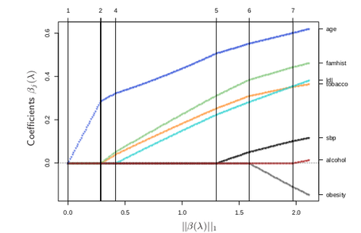

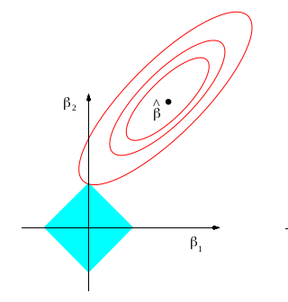

### Let's throw the Lasso!

```r
library(caret)
library(glmnet)
```

### Decision trees

#### **CART** = Classification and Regression Trees

- non-parametric
- partition of the feature space
- good for capturing interaction effects
- can overfit training data

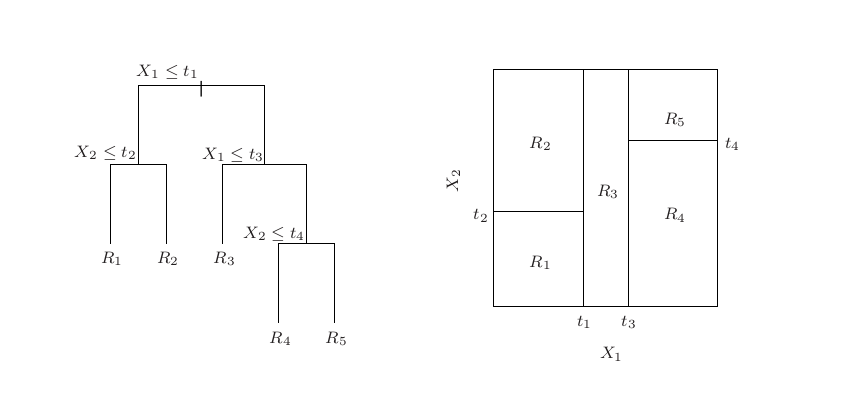

### Random forests

- Advantage: nonparametric, captures complex relationships and nonlinearity
- Disadvantage: computationally intensive, noise increases misclassification
- Algorithm: grow B trees and average prediction across all of them

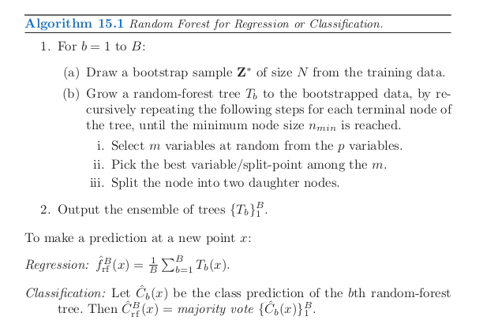

### Let's grow a forest!

```r
library(caret)
library(glmnet)
```

### Other uses with comments/tweets

- Tory vs Labour
- Remain vs Leave EU
- Democrat vs Republican
- Your data
  - any ideas?

### References

**Computational propaganda**

- Im Jane; Chandrasekharan, Eshwar; Sargent, Jackson; Lighthammer, Paige; Denby, Taylor; Bhargava, Ankit et al. (31-Jan-19): Still out there: Modeling and Identifying Russian Troll Accounts on Twitter. Available online at http://arxiv.org/pdf/1901.11162v1.
- Mihaylov, Todor; Mihaylova, Tsvetomila; Nakov, Preslav; Màrquez, Lluís; Georgiev, Georgi D.; Koychev, Ivan Kolev (2018): The dark side of news community forums: opinion manipulation trolls. In Internet Research 28 (5), pp. 1292–1312. DOI: 10.1108/IntR-03-2017-0118.
- Stukal, Denis; Sanovich, Sergey; Bonneau, Richard; Tucker, Joshua A. (2017): Detecting Bots on Russian Political Twitter. In Big data 5 (4), pp. 310–324. DOI: 10.1089/big.2017.0038.
- Woolley, Samuel; Howard, Philip N. (Eds.) (2019): Computational propaganda. Political parties, politicians, and political manipulation on social media. New York NY United States of America: Oxford University Press (Oxford studies in digital politics).

### References

**Machine Learning and Text Processing**

- Biau, Gérard; Scornet, Erwan (18-Nov-15): A Random Forest Guided Tour. Available online at http://arxiv.org/pdf/1511.05741v1.
- Friedman, Jerome; Hastie, Trevor; Tibshirani, Robert (2010): Regularization Paths for Generalized Linear Models via Coordinate Descent. In J. Stat. Soft. 33 (1). DOI: 10.18637/jss.v033.i01.
- Grimmer, Justin; Stewart, Brandon M. (2013): Text as Data: The Promise and Pitfalls of Automatic Content Analysis Methods for Political Texts. In Polit. anal. 21 (3), pp. 267–297. DOI: 10.1093/pan/mps028.
- Hastie, Trevor; Tibshirani, Robert; Friedman, J. H. (2009): The elements of statistical learning. Data mining, inference, and prediction. 2nd ed. New York: Springer (Springer series in statistics).
- James, Gareth; Witten, Daniela; Hastie, Trevor; Tibshirani, Robert (2013): An introduction to statistical learning. With applications in R. New York: Springer (Springer texts in statistics, 103).